# Internet Usage Among Latin American People

Eduard Vargas

**Monash Student ID: 34322450**

2024-06-01

#### Section 1: Loading the libraries

```r
# Loading the libraries
library(dplyr)
library(tidyr)
library(knitr)
library(kableExtra)
library(ggplot2)
library(scales)
library(RColorBrewer)
library(viridis)
library(htmltools)
```

#### Section 2: Research Question

Given that technological advancements are often first adopted in developed countries with the necessary resources and infrastructure, this is not typically the case for Latin American countries. What has been the growth in internet usage among people in Latin America from 1990 to the present, and how does it compare to that of a first-world country?

#### Data set introduction:

The data set extracted from [Our World in Data](https://ourworldindata.org/internet) (For the citation, please see the last part of this work). This is an organisation that focuses on making research and data on major global issues like poverty, disease, hunger, climate change, war, existential risks, and inequality accessible and understandable to promote progress.

On this short data set, the variables contained are the following:

```r
raw_data <- read.csv("number-of-internet-users.csv",header = TRUE)
```

```r
# Creating a new table with the count of distinct countries
countries_count <- raw_data %>%
  summarise(Count = n_distinct(Country)) %>%
  mutate(Countries = "Number of Countries") %>%
  select(Countries, Count)
```

**Variables:**

The following are the variables contained in the Data Set:

```r
# Displaying the variables:

print(colnames(raw_data))
```

```
## [1] "Country"                  "Country_Code"
## [3] "Year"                     "Number_of_Internet_Users"
```

- **Country:** Refers to the 224 distinct Countries contained in the original Data Set.

```r
# Creating a new table with the count of distinct countries
new_table <- raw_data %>%
  summarise(Count = n_distinct(Country)) %>%
  mutate(Row = "Number of Countries") %>%
  select(Row, Count)

# Displaying the table
kable(new_table, col.names = c("Description", "Count"), caption = "Summary of Data")
```

(#tab:counting the distinc countries)Summary of Data

| Description | Count |
| --- | --- |
| Number of Countries | 224 |

- **Country_Code:**

Refers to the specific code allocated for each country

- **Year:**

Refers to the Years contained.This data contained year 1990 to 2020

```r
# Calculate the minimum and maximum years
min_year <- min(raw_data$Year, na.rm = TRUE)
max_year <- max(raw_data$Year, na.rm = TRUE)

# Create a data frame with these values
min_max_years <- data.frame(
  `Min and Max Years` = c("Minimum Year", "Maximum Year"),
  Year = c(min_year, max_year)
)

# Display the data frame:
kable(min_max_years, col.names = c("Description", "Year"), caption = "Minimum and Maximum Years") %>%
  kable_styling(position = "center")
```

(#tab:Min and Max Years)(#tab:Min and Max Years)Minimum and Maximum Years

| Description | Year |
| --- | --- |
| Minimum Year | 1990 |
| Maximum Year | 2020 |

- **Number_of_Internet_Users:**

Refers to the number of people using (having access) to internet for each year according to the statistics in the data set.

### Section 4: Data set description

The dataset raw_data provides insights into internet usage across different countries. It comprises 6,406 entries, with each entry detailing a specific country, its corresponding code, the year, and the number of internet users. The dataset spans from 1990 to 2020. The number of internet users ranges widely, from 0 to an astounding 4.7 billion, reflecting the exponential growth of internet adoption over the years. The median year in the dataset is 2005, with key statistical quartiles at 1997 and 2012, highlighting significant periods in the dataset’s timeline.

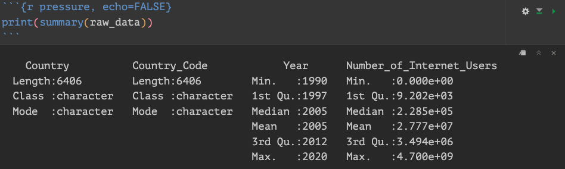

**Data types:**

The Raw data contains the following formats:

```r
str(raw_data)
```

```
## 'data.frame':    6406 obs. of  4 variables:
##  $ Country                 : chr  "Afghanistan" "Afghanistan" "Afghanistan" "Afghanistan" ...
##  $ Country_Code            : chr  "AFG" "AFG" "AFG" "AFG" ...
##  $ Year                    : int  1990 1991 1992 1993 1994 1995 2001 2002 2003 2004 ...
##  $ Number_of_Internet_Users: num  0 0 0 0 0 ...
```

### Section 5: Data summary

In order to resolve the question, I will group the Latin American Countries, and the Northern ones. Subsequently, I will take the mean for each year between these 2 groups and I will compare by year. This will provide an general glimpse on the difference in growth and behavior throughout these time.

```r
# List of Latin American Countries:

latin_american_countries <- c("Argentina","Belize","Bolivia",
                              "Brazil","Chile","Colombia","Costa Rica",
                              "Cuba", "Dominican Republic", "Ecuador",
                              "El Salvador","Guatemala","Haiti", "Honduras",
                              "Jamaica", "Mexico", "Nicaragua","Panama", "Paraguay",
                              "Peru","Puerto Rico", "Suriname", "Trinidad and Tobago",
                              "Uruguay", "Venezuela")

# Filter the data to include only Latin American countries
Latin_America <- raw_data %>%
  filter(Country %in% latin_american_countries)
```

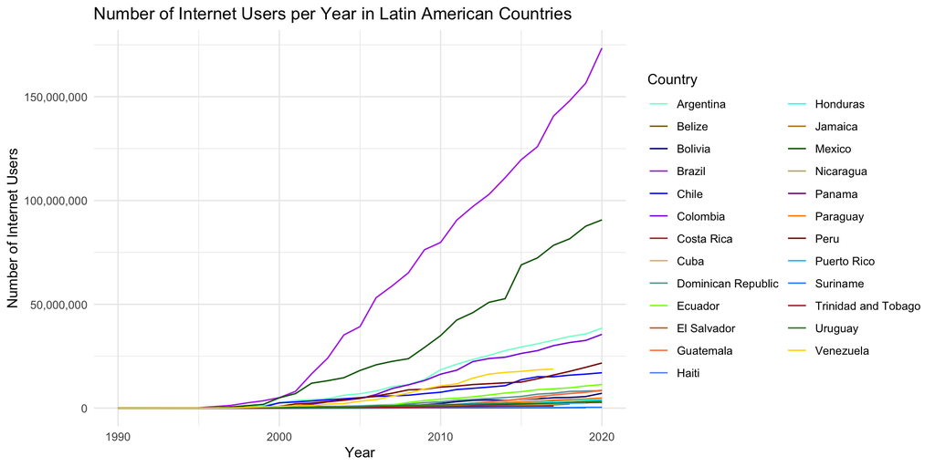

```r
# Defining my own color palette

custom_palette <- c("aquamarine", "darkgoldenrod4", "navyblue", "darkorchid2", "blue",
                    "blueviolet", "brown", "burlywood", "cadetblue", "chartreuse",
                    "chocolate", "coral", "cornflowerblue", "cyan", "darkgoldenrod",
                    "darkgreen", "darkkhaki", "darkmagenta", "darkorange", "darkred",
                    "deepskyblue", "dodgerblue", "firebrick", "forestgreen", "gold")

# Plotting the individual data:
Latino_ind_stats <- ggplot(Latin_America, aes(x = Year, y = Number_of_Internet_Users, color = Country)) +
  geom_line() +
  scale_color_manual(values = custom_palette) +
  labs(title = "Number of Internet Users per Year in Latin American Countries",
       x = "Year",
       y = "Number of Internet Users",
       color = "Country") +
    scale_y_continuous(labels = comma) +
  theme_minimal()

# Display the plot
print(Latino_ind_stats)
```

As expected, the growth is exponential. Nonetheless, it is very interesting to see how Brazil is the country with the biggest pivot upwards from starting from the year 2000. Followed by Mexico, which is the second country with the highest amount of users on the Internet. The rest of the Latin American countries tend to behave in the same way.

As previously mentioned, in order to perform a general analysis as a group, I will use the mean of users per year for the group.

Now let’s see the behavior of the Northern American Countries (USA and Canada for this work).

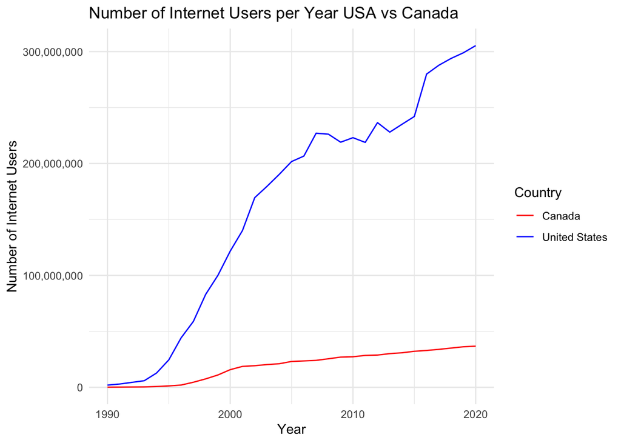

```r
# Grouping USA and Canada for the North American Countries

usa_and_canada <- raw_data %>%
  filter(Country %in% c("United States", "Canada"))


# Visualizing the behavior per year

USA_n_Canda_PYPLOT <-
  ggplot(usa_and_canada, aes(x = Year, y = Number_of_Internet_Users, color = Country)) +
  geom_line() +
  labs(title = "Number of Internet Users per Year USA vs Canada",
       x = "Year",
       y = "Number of Internet Users",
       color = "Country") +
  scale_color_manual(values = c("United States" = "blue", "Canada" = "red")) +
  scale_y_continuous(labels = comma) +
  theme_minimal()

print(USA_n_Canda_PYPLOT)
```

**Observations:**

```r
# Display tables side by side
div(
  style = "display: flex; justify-content: space-between;",
  div(style = "width: 45%;", HTML(LA_table)),
  div(style = "width: 45%;", HTML(USA_CA_table))
)
```

(\#tab:Grouping and Calculating Mean)Summary of Internet Users in Latin American Countries by Year

| Year | Mean Internet Users | Min Internet Users | Max Internet Users |
| --- | --- | --- | --- |
| 1990 | 0 | 0 | 0 |
| 1991 | 398 | 0 | 5,042 |
| 1992 | 1,761 | 0 | 20,183 |
| 1993 | 3,937 | 0 | 40,400 |
| 1994 | 8,174 | 0 | 60,646 |
| 1995 | 19,981 | 0 | 171,917 |
| 1996 | 60,019 | 582 | 748,477 |
| 1997 | 123,446 | 2,798 | 1,324,911 |
| 1998 | 247,236 | 1,935 | 2,527,755 |
| 1999 | 418,754 | 5,800 | 3,536,921 |
| 2000 | 803,961 | 12,006 | 5,048,780 |
| 2001 | 1,230,104 | 14,936 | 8,070,316 |
| 2002 | 1,885,125 | 14,552 | 16,512,580 |
| 2003 | 2,532,013 | 23,778 | 24,120,920 |
| 2004 | 3,150,172 | 26,670 | 35,233,276 |
| 2005 | 3,680,455 | 33,055 | 39,269,933 |
| 2006 | 4,655,882 | 49,591 | 53,206,613 |
| 2007 | 5,385,970 | 73,107 | 58,912,694 |
| 2008 | 6,090,454 | 80,396 | 65,181,049 |
| 2009 | 7,209,925 | 85,456 | 76,289,786 |
| 2010 | 8,149,433 | 90,836 | 79,817,702 |
| 2011 | 9,341,460 | 101,171 | 90,550,859 |
| 2012 | 10,364,988 | 104,491 | 97,109,180 |
| 2013 | 11,221,423 | 115,818 | 102,958,796 |
| 2014 | 11,963,180 | 136,357 | 110,989,278 |
| 2015 | 13,474,814 | 149,676 | 119,682,082 |
| 2016 | 14,397,065 | 163,739 | 125,920,682 |
| 2017 | 15,756,566 | 176,420 | 140,680,972 |
| 2018 | 17,248,658 | 190,274 | 148,029,327 |
| 2019 | 19,049,701 | 197,664 | 156,533,889 |
| 2020 | 22,537,029 | 425,312 | 173,419,624 |

(\#tab:Grouping and Calculating Mean)Summary of Internet Users in United States and Canada by Year

| Year | Mean Internet Users | Min Internet Users | Max Internet Users |
| --- | --- | --- | --- |
| 1990 | 1,023,313 | 99,842 | 1,946,784 |
| 1991 | 1,542,965 | 159,798 | 2,926,132 |
| 1992 | 2,329,699 | 259,659 | 4,399,739 |
| 1993 | 3,109,110 | 339,591 | 5,878,630 |
| 1994 | 6,721,582 | 689,374 | 12,753,789 |
| 1995 | 12,879,386 | 1,219,473 | 24,539,300 |
| 1996 | 23,083,054 | 2,000,616 | 44,165,492 |
| 1997 | 31,693,062 | 4,504,035 | 58,882,089 |
| 1998 | 45,256,424 | 7,505,275 | 83,007,572 |
| 1999 | 55,541,814 | 11,000,597 | 100,083,031 |
| 2000 | 68,697,738 | 15,740,541 | 121,654,935 |
| 2001 | 79,387,483 | 18,663,667 | 140,111,299 |
| 2002 | 94,400,177 | 19,292,500 | 169,507,854 |
| 2003 | 99,953,029 | 20,299,690 | 179,606,368 |
| 2004 | 105,701,581 | 21,047,649 | 190,355,513 |
| 2005 | 112,422,054 | 23,085,925 | 201,758,182 |
| 2006 | 115,088,221 | 23,553,070 | 206,623,372 |
| 2007 | 125,556,431 | 24,055,318 | 227,057,544 |
| 2008 | 125,846,428 | 25,478,621 | 226,214,235 |
| 2009 | 123,009,731 | 26,975,919 | 219,043,543 |
| 2010 | 125,179,808 | 27,272,624 | 223,086,991 |
| 2011 | 123,676,502 | 28,488,535 | 218,864,469 |
| 2012 | 132,666,394 | 28,794,257 | 236,538,532 |
| 2013 | 129,059,264 | 30,084,652 | 228,033,875 |
| 2014 | 132,964,644 | 30,844,502 | 235,084,785 |
| 2015 | 137,083,818 | 32,158,908 | 242,008,728 |
| 2016 | 156,415,583 | 32,921,097 | 279,910,069 |
| 2017 | 160,855,652 | 33,886,378 | 287,824,925 |
| 2018 | 164,495,224 | 35,050,170 | 293,940,279 |
| 2019 | 167,596,164 | 36,209,294 | 298,983,035 |
| 2020 | 171,055,988 | 36,740,677 | 305,371,298 |

**Observations:**

Visually, the growth between both groups will look like this:

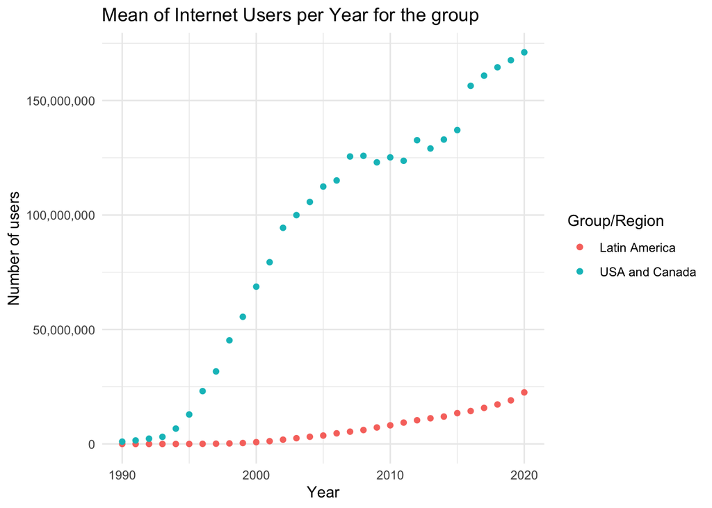

```r
# Joining both groups together in a single data set
# Selecting the columns Year and Mean_Internet_Users from both data frames
latin_america_selected <- latin_america_stats_per_year %>%
  select(Year, Mean_Internet_Users)

us_canada_selected <- us_canada_stats_per_year %>%
  select(Year, Mean_Internet_Users)

# Performing the join on the 'Year' column
LA_n_N <- latin_america_selected %>%
  left_join(us_canada_selected, by = "Year", suffix = c("_Latin_America", "_USA_CDA"))


# Renaming the columns for easier differentiation

LA_n_N <- LA_n_N %>% rename(
  Latin_America = Mean_Internet_Users_Latin_America,
  USA_CDA = Mean_Internet_Users_USA_CDA
)

# Passing to numeric in order to plot

LA_n_N <- LA_n_N %>%
  mutate(
    Latin_America = as.numeric(gsub(",","",Latin_America)),
    USA_CDA = as.numeric(gsub(",","",USA_CDA))
  )

# Creating the visualization:

LA_n_N_plot <-
  ggplot(LA_n_N, aes(x = Year)) +
  geom_point(aes(y = Latin_America, color = 'Latin America')) +
  geom_point(aes(y = USA_CDA, color = 'USA and Canada')) +
  labs(title = "Mean of Internet Users per Year for the group",
       x = "Year",
       y = "Number of users",
       color = "Group/Region") +
  scale_y_continuous(labels = scales :: comma) +
  theme_minimal()

print(LA_n_N_plot)
```

### Conclusions:

Conclusion The journey of Internet adoption from 1990 to 2020 unveils a compelling narrative of digital divide and growth. In North America, led by the USA, the Internet saw explosive uptake right from the early 90s, with over a million users online in 1990 alone. This early adoption set the stage for continuous and significant growth, averaging millions of new users each year. By contrast, Latin America’s digital story started more modestly. With virtually no users in 1990, the region’s Internet usage began to pick up pace only later, reflecting broader socio-economic challenges and infrastructural gaps.

These patterns underscore the profound influence of economic capacity, infrastructure, and policy on technological adoption. North America’s rapid and vast Internet growth stands as a testament to early investment and socio-economic readiness, while Latin America’s story reflects a determined climb towards digital inclusion, setting the stage for future potential and growth.

### Citations:

- International Telecommunication Union (via World Bank); Gapminder (2019); UN (2022); HYDE (2017); Gapminder (Systema Globalis) – processed by Our World in Data. “Number of Internet users” [dataset]. International Telecommunication Union (via World Bank); Gapminder (2019); UN (2022); HYDE (2017); Gapminder (Systema Globalis) [original data].